# Project 1

### **Obtaining The Dataframes**

The dataframes were obtained from an oracle database on RestfulRel server. The code that handles dataframe creation can be found in 01 Data folder. In order to visualize the data in the next step, the user must run all 5 R files in that folder to generate the necessary dataframes. The dataframes are of the following (head is used to save space):

**Customer Dataframe**

```r
source("../01_Data/Dataframe_C.R", echo=TRUE)
```

```
##
## > library("bitops")
##
## > library("RCurl")
##
## > dfc <- data.frame(eval(parse(text = substring(getURL(URLencode("http://129.152.144.84:5001/rest/native/?query=\"select * from customers\""),
## +      .... [TRUNCATED]
##
## > head(dfc)
##   CUSTOMER_ID CUSTOMER_FIRST_NAME CUSTOMER_LAST_NAME      CUSTOMER_ADDRESS
## 1           1               Korah             Blanca       1555 W Lane Ave
## 2           2                Yash            Randall 11 E Rancho Madera Rd
## 3           3           Johnathon          Millerton        60 Madison Ave
## 4           4             Mikayla             Damion      2021 K Street Nw
## 5           5             Kendall              Mayte 4775 E Miami River Rd
## 6           6             Kaitlin           Hostlery 3250 Spring Grove Ave
##   CUSTOMER_CITY CUSTOMER_STATE CUSTOMER_ZIP CUSTOMER_PHONE CUSTOMER_FAX
## 1      Columbus             OH        43221     6145554432   6145553920
## 2       Madison             WI        53707     2095551205   2095552262
## 3      New York             NY        10010     2125554800         NULL
## 4    Washington             DC        20006     2025555561         NULL
## 5        Cleves             OH        45002     5135553024         NULL
## 6    Cincinnati             OH        45225     8005552128   8005552640
```

**Item Dataframe**

```r
source("../01_Data/Dataframe_I.R", echo=TRUE)
```

```
##
## > library("bitops")
##
## > library("RCurl")
##
## > dfi <- data.frame(eval(parse(text = substring(getURL(URLencode("http://129.152.144.84:5001/rest/native/?query=\"select * from items\""),
## +     http .... [TRUNCATED]
##
## > head(dfi)
##   ITEM_ID                                       TITLE
## 1       1                            Umami In Concert
## 2       2                             Race Car Sounds
## 3       3                       No Rest For The Weary
## 4       4 More Songs About Structures and Comestibles
## 5       5               On The Road With Burt Ruggles
## 6       6                            No Fixed Address
##                  ARTIST UNIT_PRICE
## 1                 Umami         17
## 2         The Ubernerds         13
## 3 No Rest For The Weary         16
## 4 No Rest For The Weary         17
## 5          Burt Ruggles         17
## 6 Sewed the Vest Pocket         16
```

**Order Dataframe**

```r
source("../01_Data/Dataframe_O.R", echo=TRUE)
```

```
##
## > library("bitops")
##
## > library("RCurl")
##
## > dfo <- data.frame(eval(parse(text = substring(getURL(URLencode("http://129.152.144.84:5001/rest/native/?query=\"select * from orders\""),
## +     htt .... [TRUNCATED]
##
## > head(dfo)
##   ORDER_ID CUSTOMER_ID          ORDER_DATE        SHIPPED_DATE
## 1       19           1 2012-10-23 00:00:00 2012-10-28 00:00:00
## 2       29           8 2012-11-05 00:00:00 2012-11-11 00:00:00
## 3       32          11 2012-11-10 00:00:00 2012-11-13 00:00:00
## 4       45           2 2012-11-25 00:00:00 2012-11-30 00:00:00
## 5       70          10 2012-12-28 00:00:00 2013-01-07 00:00:00
## 6       89          22 2013-01-20 00:00:00 2013-01-22 00:00:00
```

**Order Detail Dataframe**

```r
source("../01_Data/Dataframe_D.R", echo=TRUE)
```

```
##
## > library("bitops")
##
## > library("RCurl")
##
## > dfd <- data.frame(eval(parse(text = substring(getURL(URLencode("http://129.152.144.84:5001/rest/native/?query=\"select * from order_details\""),
## +  .... [TRUNCATED]
##
## > head(dfd)
##   ORDER_ID ITEM_ID ORDER_QTY
## 1      381       1         1
## 2      601       9         1
## 3      442       1         1
## 4      523       9         1
## 5      630       5         1
## 6      778       1         1
```

### **Visualizing The Data**

After obtaining the dataframes from 01 Data folder, go into 02 Visualization folder and run Plot.R. This file will generate 7 plots; 4 of which are for each of the dataframes shown above and the last 3 for analysis of the overall data.

**Customer Plot**

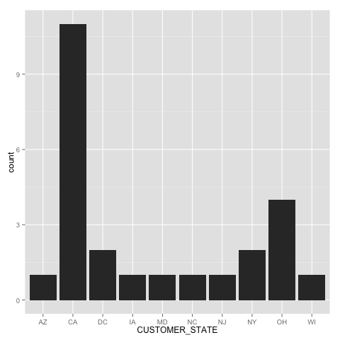

**Item Plot**

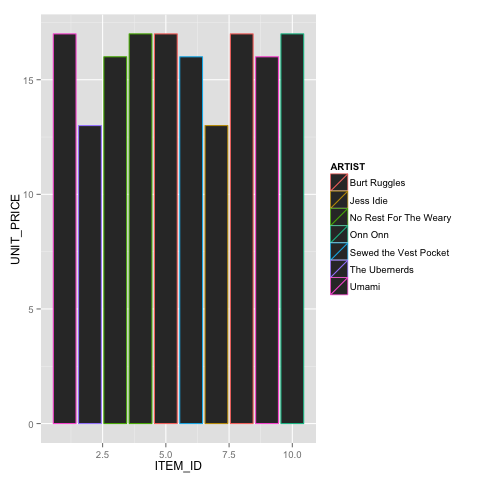

This plot shows the price of each item being sold.

**Order Plot**

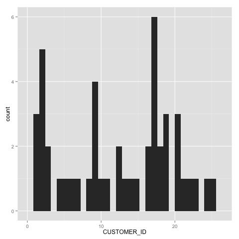

This plot shows the number of orders for each customer. There are a few customers that had not ordered anything. Reaching out to those people could increase or improve business.

**Order Detail Plot**

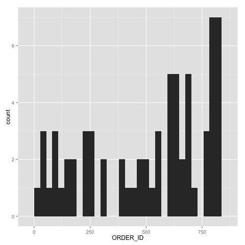

This plot shows the number of items sold for each order. As time passes, the number of items per order seem to be increasing.

**Reproduction Plots**

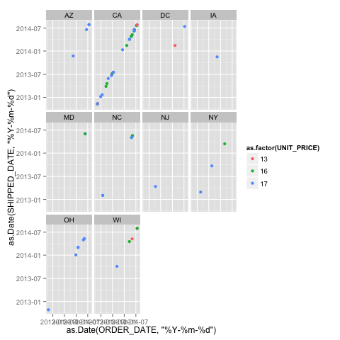

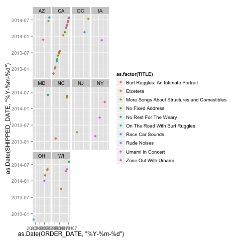

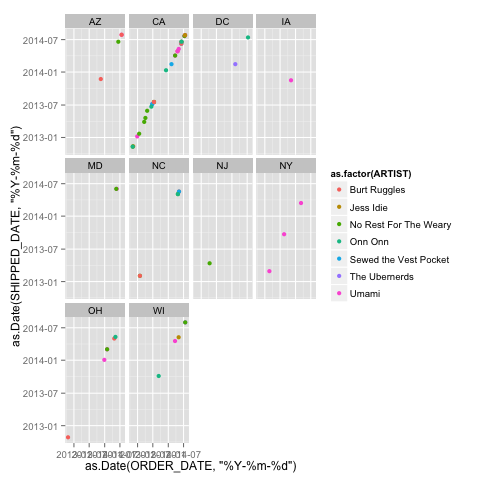